# ADP Practice 1

Ku, Bonseong

2020-12-01

## 데이터, 패키지 로드

```r
library(reshape2)
library(arules)
library(dplyr)
library(tm)
library(rJava)
library(KoNLP)
library(wordcloud)
library(plyr)
library(stringr)

lotto<-read.csv('lotto.csv') # 정형 데이터 마이닝 데이터
fifa<-read.csv('FIFA.csv', encoding='UTF-8') # 통계분석 데이터
movie<-readLines('영화 기생충_review.txt') # 비정형 텍스트 마이닝 데이터 1
dic<-readLines('영화 기생충_사전.txt') # 비정형 텍스트 마이닝 데이터 1
```

## 정형 데이터 마이닝

### 트랜잭션 데이터 변환

```r
sum(is.na(lotto))
```

```
## [1] 0
```

- 결측치 없음

```r
lot_melt<-melt(lotto, id.vars=1)
lot_melt2<-lot_melt[-2]

lot_sp<-split(lot_melt2$value,lot_melt2$time_id)
lot_ts<-as(lot_sp,"transactions")
arules::inspect(lot_ts[1:5])
```

```
##     items               transactionID
## [1] {10,23,29,33,37,40} 1
## [2] {9,13,21,25,32,42}  2
## [3] {11,16,19,21,27,31} 3
## [4] {14,27,30,31,40,42} 4
## [5] {16,24,29,40,41,42} 5
```

- lotto 데이터를 트랜잭션 데이터로 변환시켜 준다.
- 트랜잭션 ID에 따른 데이터이다.

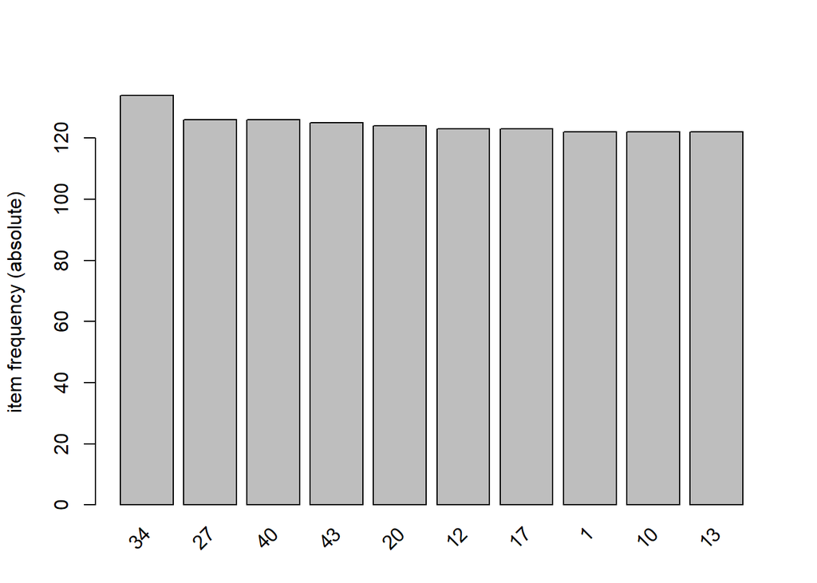

```r
itemFrequencyPlot(lot_ts,topN=10,type='absolute')
```

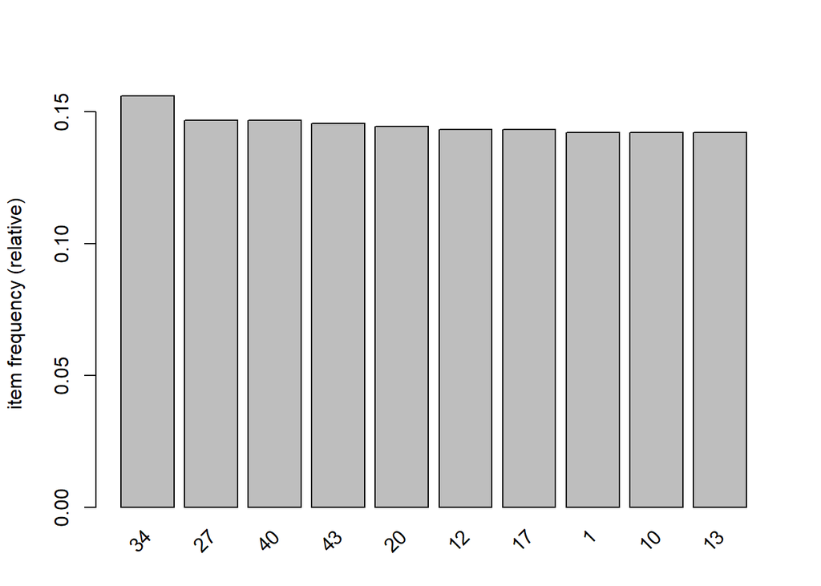

```r
itemFrequencyPlot(lot_ts,topN=10)
```

- 그 중 상위 10개의 가장 많이 나온 차트다.
- 34, 27의 숫자가 가장 많이 나온 것을 알 수 있다.

### 연관규칙 생성, 결과 해석

```r
metric.params <- list(supp=0.002, conf=0.8, minlen=2, maxlen=6)
rules_1<-apriori(lot_ts, metric.params)
```

```
## Apriori
##
## Parameter specification:
##  confidence minval smax arem  aval originalSupport maxtime support minlen
##         0.8    0.1    1 none FALSE            TRUE       5   0.002      2
##  maxlen target   ext
##       6  rules FALSE
##
## Algorithmic control:
##  filter tree heap memopt load sort verbose
##     0.1 TRUE TRUE  FALSE TRUE    2    TRUE
##
## Absolute minimum support count: 1
##
## set item appearances ...[0 item(s)] done [0.00s].
## set transactions ...[45 item(s), 859 transaction(s)] done [0.00s].
## sorting and recoding items ... [45 item(s)] done [0.00s].
## creating transaction tree ... done [0.00s].
## checking subsets of size 1 2 3 4 5 done [0.00s].
## writing ... [679 rule(s)] done [0.00s].
## creating S4 object  ... done [0.00s].
```

```r
rules_2<-sort(rules_1, by='lift', decreasing = TRUE)
```

- 지지도 0.002, 신뢰도 0.8, 최소조합 항목 수 2개, 최대조합 항목 수 6개의 기준으로 연관규칙을 설정한다.

```r
rules_3<-arules::inspect(rules_2[1:30])
```

```
##      lhs              rhs  support     confidence lift     count
## [1]  {32,38,43}    => {9}  0.002328289 1          9.651685 2
## [2]  {7,23,28}     => {9}  0.002328289 1          9.651685 2
## [3]  {18,23,35}    => {9}  0.002328289 1          9.651685 2
## [4]  {14,17,33}    => {9}  0.002328289 1          9.651685 2
## [5]  {7,23,29}     => {22} 0.002328289 1          9.336957 2
## [6]  {10,27,42}    => {22} 0.002328289 1          9.336957 2
## [7]  {25,31,45}    => {22} 0.002328289 1          9.336957 2
## [8]  {21,26,37}    => {22} 0.002328289 1          9.336957 2
## [9]  {24,36,38}    => {22} 0.002328289 1          9.336957 2
## [10] {7,24,31}     => {22} 0.002328289 1          9.336957 2
## [11] {7,31,34}     => {22} 0.002328289 1          9.336957 2
## [12] {33,36,37}    => {22} 0.002328289 1          9.336957 2
## [13] {10,34,36}    => {22} 0.002328289 1          9.336957 2
## [14] {10,34,36,44} => {22} 0.002328289 1          9.336957 2
```

[output cut: 16 more lines]

```r
rules_4<-as(rules_3, 'data.frame')
write.csv(rules_4, 'lotto_rules.csv')
```

### 연관규칙에 대한 인사이트

```r
summary(rules_1)
```

```
## set of 679 rules
##
## rule length distribution (lhs + rhs):sizes
##   4   5
## 632  47
##
##    Min. 1st Qu.  Median    Mean 3rd Qu.    Max.
##   4.000   4.000   4.000   4.069   4.000   5.000
##
## summary of quality measures:
##     support           confidence      lift           count
##  Min.   :0.002328   Min.   :1    Min.   :6.410   Min.   :2.000
##  1st Qu.:0.002328   1st Qu.:1    1st Qu.:7.041   1st Qu.:2.000
##  Median :0.002328   Median :1    Median :7.280   Median :2.000
##  Mean   :0.002364   Mean   :1    Mean   :7.434   Mean   :2.031
##  3rd Qu.:0.002328   3rd Qu.:1    3rd Qu.:7.670   3rd Qu.:2.000
##  Max.   :0.003492   Max.   :1    Max.   :9.652   Max.   :3.000
##
## mining info:
##    data ntransactions support confidence
##  lot_ts           859   0.002        0.8
```

- 총 679개의 연관규칙이 도출되었으며, 그중 632개의 규칙은 4개의 번호로, 47개의 규칙은 5개의 번호로 구성되었다.
- 규칙에 대한 향상도에서 최솟값이 6.410으로 높게 나왔으며, 추첨번호들의 교집합 확률을 의미하는 지지도의 평균은 0.002364로 나왔다.
- 트랜잭션 데이터의 수는 859개이고, 트랜잭션 데이너 859회 동안의 로또 당첨번호들을 의미한다.

```r
rules_most_freq<-subset(rules_1, rhs %in% '34')
arules::inspect(rules_most_freq)
```

```
##      lhs              rhs  support     confidence lift     count
## [1]  {7,22,31}     => {34} 0.002328289 1          6.410448 2
## [2]  {22,24,31}    => {34} 0.002328289 1          6.410448 2
## [3]  {17,32,33}    => {34} 0.003492433 1          6.410448 3
## [4]  {23,42,45}    => {34} 0.002328289 1          6.410448 2
## [5]  {15,19,41}    => {34} 0.002328289 1          6.410448 2
## [6]  {2,15,28}     => {34} 0.002328289 1          6.410448 2
## [7]  {5,13,29}     => {34} 0.002328289 1          6.410448 2
## [8]  {5,17,29}     => {34} 0.002328289 1          6.410448 2
## [9]  {17,42,45}    => {34} 0.002328289 1          6.410448 2
## [10] {14,25,44}    => {34} 0.002328289 1          6.410448 2
## [11] {2,15,21}     => {34} 0.002328289 1          6.410448 2
## [12] {19,21,44}    => {34} 0.002328289 1          6.410448 2
## [13] {2,4,31}      => {34} 0.003492433 1          6.410448 3
## [14] {7,24,31}     => {34} 0.002328289 1          6.410448 2
## [15] {12,36,37}    => {34} 0.002328289 1          6.410448 2
## [16] {1,5,13}      => {34} 0.002328289 1          6.410448 2
## [17] {10,22,36,44} => {34} 0.002328289 1          6.410448 2
## [18] {7,22,24,31}  => {34} 0.002328289 1          6.410448 2
## [19] {15,19,21,44} => {34} 0.002328289 1          6.410448 2
```

## 통계분석

### 단위 변환

```r
fifa$Height_cm<-as.numeric(substr(fifa$Height,1,regexpr("'",fifa$Height)-1))*30+as.numeric(substr(fifa$Height,regexpr("'",fifa$Height)+1,nchar(as.character(fifa$Height))))*2.5
head(fifa$Height_cm)
```

```
## [1] 167.5 185.0 172.5 190.0 177.5 170.0
```

### 재범주화

```r
fifa<-within(fifa, {
  Position_Class=character(0)
  Position_Class[Position %in% c('LS','ST','RS','LW','LF','CF','RF','RW')]='Forward'
  Position_Class[Position %in% c('LAM','CAM','RAM','LM','LCM','CM','RCM','RM')]='Midfielder'
  Position_Class[Position %in% c('LWB','LDM','CDM','RDM','RWB','LB','LCB','CB','RCB','RB')]='Defender'
  Position_Class[Position %in% c('GK')]='GoalKeeper'
})

fifa$Position_Class<-factor(fifa$Position_Class, levels=c('Forward','Midfielder','Defender','GoalKeeper'), labels=c('Forward','Midfielder','Defender','GoalKeeper'))
head(fifa$Position_Class)
```

```
## [1] Forward    Forward    Forward    GoalKeeper Midfielder Forward
## Levels: Forward Midfielder Defender GoalKeeper
```

### 일원배치 분산분석 (Value~Position_class)

```r
fifa_anova<-aov(fifa$Value~fifa$Position_Class)
summary(fifa_anova)
```

```
##                        Df    Sum Sq   Mean Sq F value Pr(>F)
## fifa$Position_Class     3 4.081e+09 1.360e+09   41.87 <2e-16 ***
## Residuals           16638 5.405e+11 3.249e+07
## ---
## Signif. codes:  0 '***' 0.001 '**' 0.01 '*' 0.05 '.' 0.1 ' ' 1
```

```r
TukeyHSD(fifa_anova)
```

```
##   Tukey multiple comparisons of means
##     95% family-wise confidence level
##
## Fit: aov(formula = fifa$Value ~ fifa$Position_Class)
##
## $`fifa$Position_Class`
##                             diff        lwr        upr     p adj
## Midfielder-Forward     -169.4944  -507.0010   168.0122 0.5691282
## Defender-Forward       -930.3730 -1250.0048  -610.7412 0.0000000
## GoalKeeper-Forward    -1437.7579 -1865.9257 -1009.5900 0.0000000
## Defender-Midfielder    -760.8787 -1035.0465  -486.7108 0.0000000
## GoalKeeper-Midfielder -1268.2635 -1663.6509  -872.8761 0.0000000
## GoalKeeper-Defender    -507.3848  -887.6282  -127.1415 0.0034079
```

- 귀무가설 : 집단들 사이 평균은 같다.
- 대립가설 : 집단들 사이 평균은 같지 않다.
- 사후 분석 결과, 미드필더와 공격수 사이에서는 p-values>0.05이므로 가치가 동일하다고 할 수 있다.
- 그러나 나머지 포지션 사이에서는 <0.05이므로 가치가 동일하지 않다고 할 수 있다.
- diff 변수는 ‘-’ 앞 변수와 뒷 변수 간 반응값의 차이를 보여주는데, 일반적으로 뒷 변수가 앞 변수보다 값이 큰 것을 확인할 수 있다.

### 이원배치 분산분석 (Value~Preferred_Foot+Position_class)

```r
fifa_twoway_anova<-aov(fifa$Value~fifa$Preferred_Foot+fifa$Position_Class+fifa$Preferred_Foot:fifa$Position_Class)
summary(fifa_twoway_anova)
```

```
##                                            Df    Sum Sq   Mean Sq F value
## fifa$Preferred_Foot                         1 1.461e+08 1.461e+08   4.501
## fifa$Position_Class                         3 4.087e+09 1.362e+09  41.976
## fifa$Preferred_Foot:fifa$Position_Class     3 4.736e+08 1.579e+08   4.864
## Residuals                               16634 5.399e+11 3.246e+07
##                                          Pr(>F)
## fifa$Preferred_Foot                     0.03390 *
## fifa$Position_Class                     < 2e-16 ***
## fifa$Preferred_Foot:fifa$Position_Class 0.00221 **
## Residuals
## ---
## Signif. codes:  0 '***' 0.001 '**' 0.01 '*' 0.05 '.' 0.1 ' ' 1
```

- 귀무가설 : 주발과 가치에는 차이가 없다, 포지션과 가치에는 차이가 없다, 주발과 포지션에 상호작용이 없다.
- 대립가설 : 주발과 가치에는 차이가 있다, 포지션과 가치에는 차이가 있다, 주발과 포지션에 상호작용이 있다.
- 분산분석표를 확인한 결과, 주발과 가치에 대해서 p-values<0.05 이므로 차이가 있다고 할 수 있다.
- 포지션에 대해서는 p-values<0.05이므로 차이가 있다고 할 수 있다.
- 주발과 포지션에 대해서 p-values<0.05이므로 상호작용 효과가 있다고 할 수 있다.

### 다변량 회귀분석

```r
fifa_lm<-lm(Value~Age+Overall+Wage+Height_cm+Weight_lb, data=fifa)
step(fifa_lm,direction='both')
```

```
## Start:  AIC=261940.8
## Value ~ Age + Overall + Wage + Height_cm + Weight_lb
##
##             Df  Sum of Sq        RSS    AIC
## - Weight_lb  1 6.1905e+06 1.1392e+11 261940
## - Height_cm  1 7.6601e+06 1.1392e+11 261940
## <none>                    1.1391e+11 261941
## - Age        1 1.0961e+10 1.2487e+11 263468
## - Overall    1 2.4826e+10 1.3874e+11 265220
## - Wage       1 1.8260e+11 2.9651e+11 277859
##
## Step:  AIC=261939.7
## Value ~ Age + Overall + Wage + Height_cm
##
##             Df  Sum of Sq        RSS    AIC
## <none>                    1.1392e+11 261940
## + Weight_lb  1 6.1905e+06 1.1391e+11 261941
## - Height_cm  1 5.1404e+07 1.1397e+11 261945
## - Age        1 1.1475e+10 1.2539e+11 263535
## - Overall    1 2.4906e+10 1.3883e+11 265228
## - Wage       1 1.8264e+11 2.9656e+11 277860
```

```
##
## Call:
## lm(formula = Value ~ Age + Overall + Wage + Height_cm, data = fifa)
##
## Coefficients:
## (Intercept)          Age      Overall         Wage    Height_cm
##   -8690.818     -202.160      241.345      184.184       -8.445
```

```r
#step(lm(Value~1, data=fifa), scope=list(lower=~1,upper=~Age + Overall + Wage + Height_cm + Weight_lb), direction="both")
```

- 첫번째 모형인 Age+Overall+Wage+Height_cm+Weight_lb에 대해서 Weight_lb 변수를 제거했을 때 AIC가 가장 작은 것을 확인할 수 있었다.
- 그러므로 두번째 모형에서는 Weight_lb를 빼고 Age + Overall + Wage + Height_cm만을 확인한 결과, 이 모형이 다른 변수를 추가하거나 제거하는 것보다 AIC가 낮은 것을 확인할 수 있었다.
- 따라서 최종모형으로 Value ~ Age + Overall + Wage + Height_cm를 사용한다.
- 최종적으로 추정된 회귀식은 y = -8690.818 - 202.160 * Age + 241.345 * Overall + 184.184 * Wage - 8.445 * Height_cm 이다.

```r
fifa_lm2<-lm(Value ~ Age + Overall + Wage + Height_cm, data = fifa)
summary(fifa_lm2)
```

```
##
## Call:
## lm(formula = Value ~ Age + Overall + Wage + Height_cm, data = fifa)
##
## Residuals:
##    Min     1Q Median     3Q    Max
## -24272   -837   -120    668  58287
##
## Coefficients:
##              Estimate Std. Error t value Pr(>|t|)
## (Intercept) -8690.818    588.280  -14.77  < 2e-16 ***
## Age          -202.160      4.938  -40.94  < 2e-16 ***
## Overall       241.345      4.002   60.31  < 2e-16 ***
## Wage          184.184      1.128  163.32  < 2e-16 ***
## Height_cm      -8.445      3.082   -2.74  0.00615 **
## ---
## Signif. codes:  0 '***' 0.001 '**' 0.01 '*' 0.05 '.' 0.1 ' ' 1
##
## Residual standard error: 2617 on 16637 degrees of freedom
## Multiple R-squared:  0.7908, Adjusted R-squared:  0.7908
## F-statistic: 1.572e+04 on 4 and 16637 DF,  p-value: < 2.2e-16
```

- stepwise 방법을 이용해 변수선택 후 회귀분석을 시행할 결과, Age, Overall, Wage, Height_cm 변수는 유의수준 0.05 하에서 통계적으로 유의하다.
- 모형의 결정계수는 0.7908, 수정된 결정계수는 0.7908로 다변량 회귀식은 데이터의 약 80%를 설명하고 있다.
- 이 모형에 대한 F 통계량에 대한 p-value는 < 0.05이므로 통계적으로 유의하다고 할 수 있다.

## 비정형 데이터 마이닝

### 사전등록, 데이터 전처리

```r
#buildDictionary(ext_dic = "woorimalsam", user_dic=data.frame(readLines("영화 기생충_사전.txt"),"ncn"),replace_usr_dic = T)
movie[1:10]
```

```
##  [1] "별1개  준 사람들은   나베당임"
##  [2] "역쉬"
##  [3] "영화가 끝나고 가슴이 먹먹하고 답답햇습니다 너무나 충격적이었습니다.."
##  [4] "지금까지 나온 감독의 모든 작품이 압축되어있다는 느낌을 받음.  Bomb!!!"
##  [5] "대단한 영화. 몰입력 장난아님. 후아"
##  [6] "그닥"
##  [7] "칸하고 안맞나봄."
##  [8] "봉준호식의 코메디와 사회비판 페이소스"
##  [9] "좋았습니다"
## [10] "군더더기 없이 깔끔한 영화, 지금도 영화가 주는 메세지를 생각하는 중입니다"
```

```r
clean_txt<-function(txt){
  txt<-tolower(txt)             # 대, 소문자 변환
  txt<-removePunctuation(txt)   # 구두점 제거
  txt<-removeNumbers(txt)       # 숫자 제거
  txt<-stripWhitespace(txt)     # 공백제거

  return(txt)
}

movie_clean<-clean_txt(movie)

movie_clean[1:10]
```

```
##  [1] "별개 준 사람들은 나베당임"
##  [2] "역쉬"
##  [3] "영화가 끝나고 가슴이 먹먹하고 답답햇습니다 너무나 충격적이었습니다"
##  [4] "지금까지 나온 감독의 모든 작품이 압축되어있다는 느낌을 받음 bomb"
##  [5] "대단한 영화 몰입력 장난아님 후아"
##  [6] "그닥"
##  [7] "칸하고 안맞나봄"
##  [8] "봉준호식의 코메디와 사회비판 페이소스"
##  [9] "좋았습니다"
## [10] "군더더기 없이 깔끔한 영화 지금도 영화가 주는 메세지를 생각하는 중입니다"
```

### TDM 구축, 빈도 파악, 시각화

```r
b<-VCorpus(VectorSource(movie))

clean_corpus <- function(corpus){
  corpus <- tm_map(corpus, stripWhitespace)
  corpus <- tm_map(corpus, removePunctuation)
  corpus <- tm_map(corpus, removeNumbers)
  corpus <- tm_map(corpus, content_transformer(tolower))
  return(corpus)
}

c<-clean_corpus(b)

dtm<-TermDocumentMatrix(c,control=list(dictionary=dic))

m <- as.matrix(dtm)
v <- sort(rowSums(m),decreasing=TRUE)
d <- data.frame(word = names(v),freq=v)
head(d, 10)
```

```
##          word freq
## 봉준호 봉준호   78
## 송강호 송강호   29
## 기생충 기생충   17
## 이선균 이선균   10
## 조여정 조여정   10
## 최우식 최우식    4
## 이정은 이정은    3
## 박소담 박소담    2
## 박사장 박사장    1
## 장혜진 장혜진    1
```

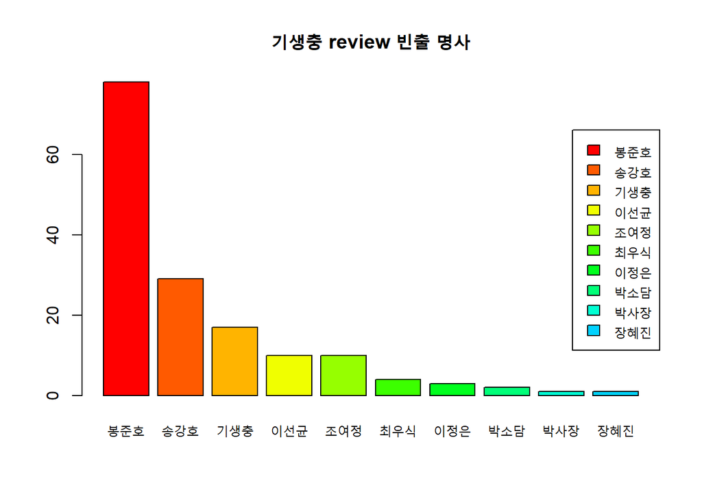

```r
colors<-rainbow(nrow(d))

barplot(v[1:10], main="기생충 review 빈출 명사",col=colors)
legend("right",names(v[1:10]),fill=colors)
```

### 명사 추출, 워드 클라우드

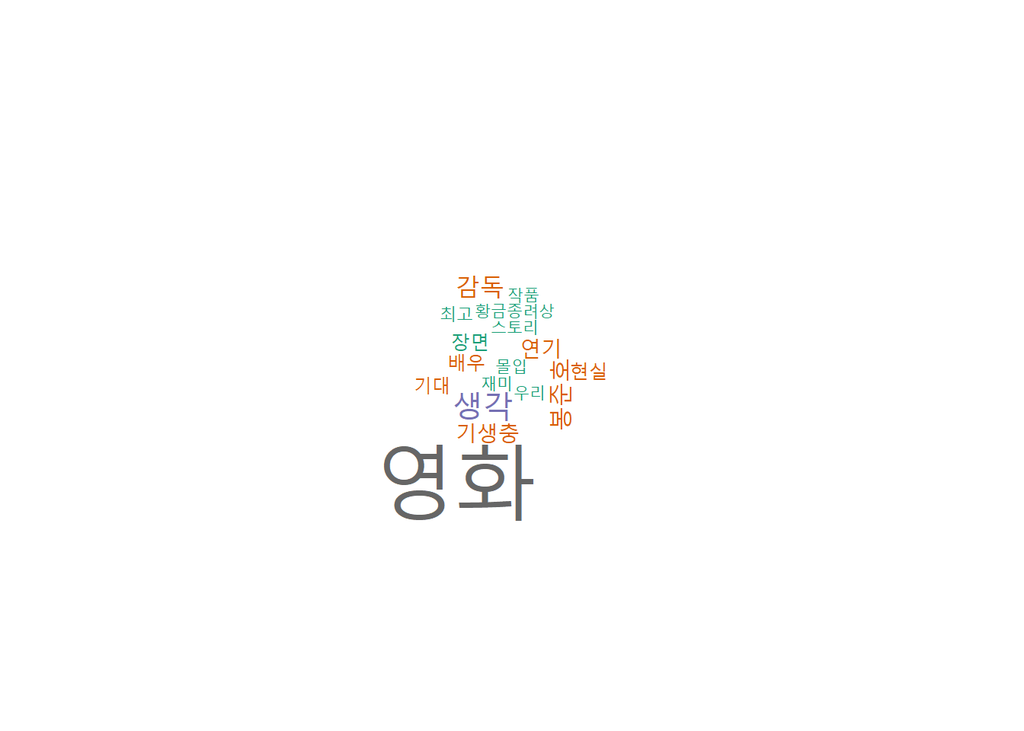

```r
movie_exN<-sapply(movie_clean,extractNoun)
Noun<-as.vector(unlist(movie_exN))
Noun_2<-Noun[nchar(Noun)>=2]

result<-data.frame(sort(table(Noun_2),decreasing=T))
t<-wordcloud(result$Noun_2,result$Freq,color=brewer.pal(8,"Dark2"),min.freq=30)
```